# Assignment Week 5

### Name: H.C. (Bram) Otten

### ULCN: s2330326

### Exercise 1

We will use the EM algorithm to estimate the parameters of a normal mixture model and study its behavior. Recall that $X$ follows a normal mixture distribution if it has density,
$$f(x; \theta) = \sum_{k = 1}^K w_k \phi(x; \mu_k, \sigma_k),$$
where

- $\theta = (w_1, \dots, w_K, \mu_1, \sigma_1, \dots, \mu_K, \sigma_K)$ is the vector of unknown parameters,
- $\phi(\cdot; \mu, \sigma)$ is the density of a $\mathcal{N}(\mu, \sigma^2)$ random variable.

Also keep in mind that there are constraints on the parameters:

- $\sum_{k = 1}^K w_k = 1$
- $\sigma_k > 0, 0 \le w_k \le 1$ for all $k = 1, \dots, K$.

**(a)** Write a function `rmixt()` that simulates from a Gaussian mixture model. The function should take four arguments:

- `n`: the number of samples to simulate,
- `w`, `mu`, `sigma`: the model parameters (length `K` vectors).

Verify that your function is correct by making a histogram of simulated data. This function will be useful to check whether your solution of (c) is correct.

**Solution**

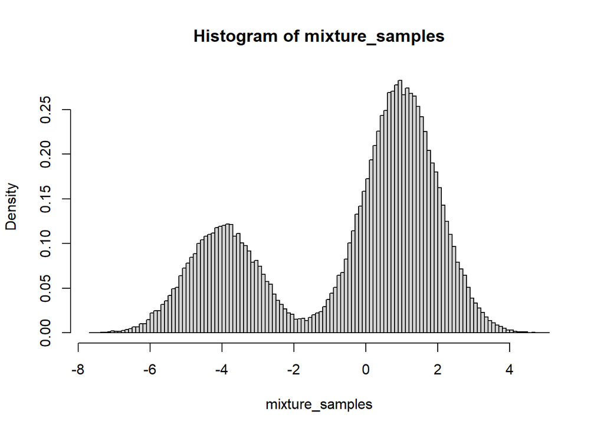

```r
rmixt <- function(n, w, mu, sigma) {
  k <- sample(1:length(w), n, replace = TRUE, prob = w)
  rnorm(n, mu[k], sigma[k])
}

w <- c(0.3, 0.7)
mu <- c(-4, 1)
sigma <- c(1, 1)
mixture_samples <- rmixt(10^5, w, mu, sigma)
hist(mixture_samples, prob = TRUE, breaks = 100)
```

The results look okay with large $n$, but this isn’t the same as $f$ exactly: the samples are from distribution $N(\mu_i, \sigma_i)$ with probability $w_i$. (I.e., not that sum.)

**(b)** Write a function `dmixt()` that computes the mixture density. It should take the following arguments:

- `x`: vector of evaluation points,
- `w`, `mu`, `sigma`: the model parameters (length `K` vectors).

Verify that your function is correct by plotting the density over a histogram of simulated data.

**Solution**

```r
dmixt <- function(x, w, mu, sigma) {
  n <- length(x)
  p <- numeric(n)
  for (i in 1:n) {
    p[i] <- sum(w * dnorm(x[i], mu, sigma))
  }
  p
}

hist(mixture_samples, prob = TRUE, breaks = 100)
x <- seq(-8, 5, length.out = 10^4)
integrate(dmixt, -8, 5, w, mu, sigma) # ~ 1, check
```

```
## 0.9999683 with absolute error < 5.6e-06
```

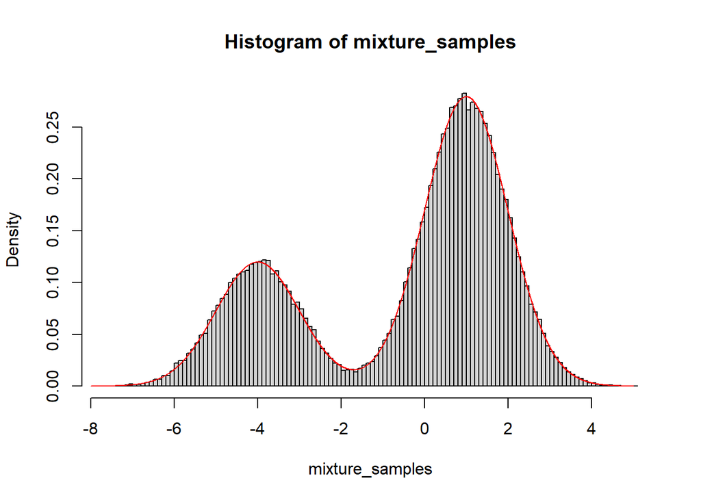

```r
lines(x, dmixt(x, w, mu, sigma), col = "red")
```

**(c)** Write a function `fit_em()` that implements the EM algorithm for fitting the Gaussian mixture parameters. The function should take four arguments

- `x`: the data,
- `w, mu, sigma`: initial guesses for parameters.

It should return a matrix with columns `(w, mu, sigma)`.

**Solution**

```r
fit_em <- function(x, w, mu, sigma, approx) {
  N <- length(x)
  K <- length(w)
  theta <- matrix(data = c(w, mu, sigma), nrow = K, ncol = 3)
  repeat {
    old_theta <- theta  # R makes this a copy, not a ref.
    w <- theta[1:K, 1]
    mu <- theta[1:K, 2]
    sigma <- theta[1:K, 3]

    # Not really an E and M step because I use the approximations.
    dm <- dmixt(x, w, mu, sigma)
    p_i_k <- matrix(nrow = N, ncol = K)
    for (k in 1:K){
      p_i_k[,k] <- w[k] * dnorm(x, mu[k], sigma[k]) / dm
    }

    p_i_k_sums <- colSums(p_i_k)
    for (k in 1:K) {
      w[k] <- p_i_k_sums[k] / sum(p_i_k_sums)
      mu[k] <- sum(x * p_i_k[1:N, k]) / p_i_k_sums[k]
      sigma[k] <- sqrt(sum((x - mu[k])^2 * p_i_k[1:N, k]) / p_i_k_sums[k])
    }

    # Break
    theta <- matrix(data = c(w, mu, sigma), nrow = K, ncol = 3)
    diff <- norm(theta - old_theta, type = "O")
    if (diff < approx) break
  }
  colnames(theta) <- c("w", "mu", "sigma")
  theta
}
```

```r
print("True:")
```

```
## [1] "True:"
```

```r
matrix(data = c(w, mu, sigma), nrow = 2, ncol = 3)
```

```
##      [,1] [,2] [,3]
## [1,]  0.3   -4    1
## [2,]  0.7    1    1
```

```r
fit_em(mixture_samples, c(0.6, 0.4), c(-1, 3), c(1, 2), 0.0001)
```

```
##              w         mu     sigma
## [1,] 0.3026596 -4.0004995 1.0007354
## [2,] 0.6973404  0.9977161 0.9996193
```

```r
fit_em(mixture_samples, w, mu, sigma, 0.0001)
```

```
##              w         mu     sigma
## [1,] 0.3026522 -4.0005591 1.0006717
## [2,] 0.6973478  0.9976889 0.9996501
```

**(d)**

We will now investigate the role of the starting parameters. We will use the following data:

```r
set.seed(5)
w_true <- c(0.2, 0.3, 0.5)
mu_true <- c(0.5, 2, 4)
sigma_true <- c(0.5, 1, 0.5)
approx <- 0.0001
n <- 1000  # default
# n <- 10^5  # makes everything but method 2 do ~ perfectly in okay time
X <- rmixt(n, w_true, mu_true, sigma_true)
```

Consider the following choices of initial guesses:

1. `w <- w_true; mu <- mu_true; sigma <- sigma_true`.
2. `w <- rep(1/3, 3); mu <- rep(mean(X), 3); sigma <- rep(sd(X), 3)`
3. `w <- rep(1/3, 3); mu <- mean(X) + sd(X) * c(-1, 0, 1); sigma <- rep(sd(X), 3)`
4. The group frequency/mean/SD where groups are computed via the k-means algorithm:

```r
clusters <- kmeans(X, 3)$cluster
w <- table(clusters) / length(X)
mu <- tapply(X, clusters, mean)
sigma <- tapply(X, clusters, sd)
```

For every choice of starting parameters, run the EM algorithm and compare the estimated densities with a histogram. Which methods can you recommend for practical use?

**Solution**

##### 1.

```r
theta1 <- fit_em(X, w_true, mu_true, sigma_true, approx)
theta1
```

```
##              w        mu     sigma
## [1,] 0.3057422 0.6995526 0.6118072
## [2,] 0.1344130 2.2683036 0.4324269
## [3,] 0.5598448 3.9517146 0.5355290
```

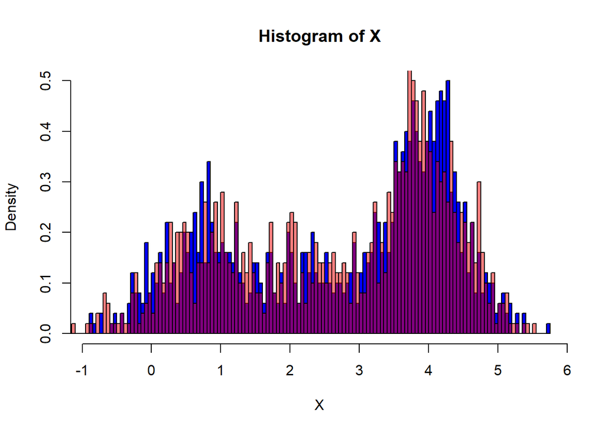

```r
hist(X, prob = TRUE, breaks = 100, col = "blue")
hist(rmixt(n, theta1[1:3, 1], theta1[1:3, 2], theta1[1:3, 3]),
     breaks = 100, prob = TRUE, add = TRUE, col=rgb(1,0,0,0.5))
```

This method is not useful in practice (true parameters already known) but works perfectly.

##### 2.

```r
theta2 <- fit_em(X, rep(1/3, 3), rep(mean(X), 3), rep(sd(X), 3), approx)
theta2
```

```
##              w       mu    sigma
## [1,] 0.3333333 2.731119 1.557206
## [2,] 0.3333333 2.731119 1.557206
## [3,] 0.3333333 2.731119 1.557206
```

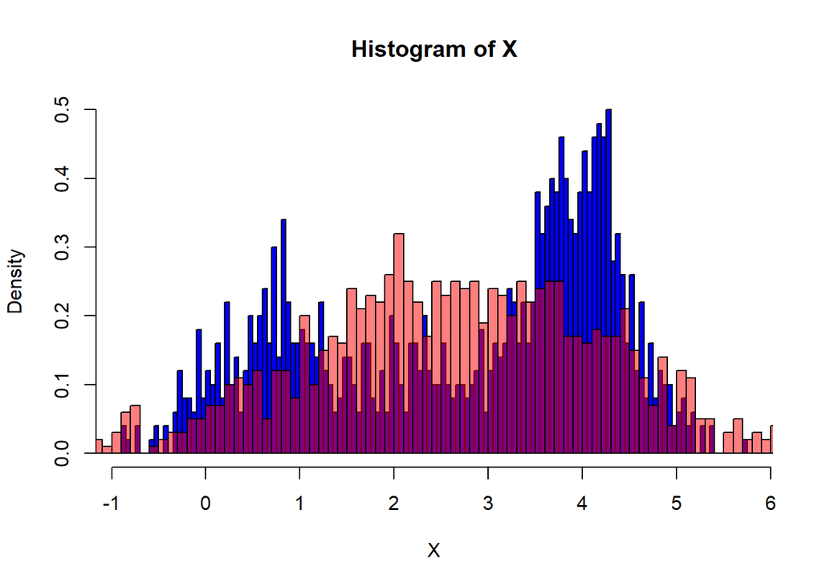

```r
hist(X, prob = TRUE, breaks = 100, col = "blue")
hist(rmixt(n, theta2[1:3, 1], theta2[1:3, 2], theta2[1:3, 3]),
     breaks = 100, prob = TRUE, add = TRUE, col=rgb(1,0,0,0.5))
```

This method apparently messes up the (approximate solutions for the) EM algorithm – we start off in a local minimum-like situation we can’t get out of.

##### 3.

```r
theta3 <- fit_em(X, rep(1/3, 3), rep(mean(X) + sd(X) * c(-1, 0, 1), 3),
                 rep(sd(X), 3), approx)
theta3
```

```
##              w        mu     sigma
## [1,] 0.3057450 0.6995612 0.6118122
## [2,] 0.1344082 2.2683056 0.4324109
## [3,] 0.5598468 3.9517113 0.5355313
```

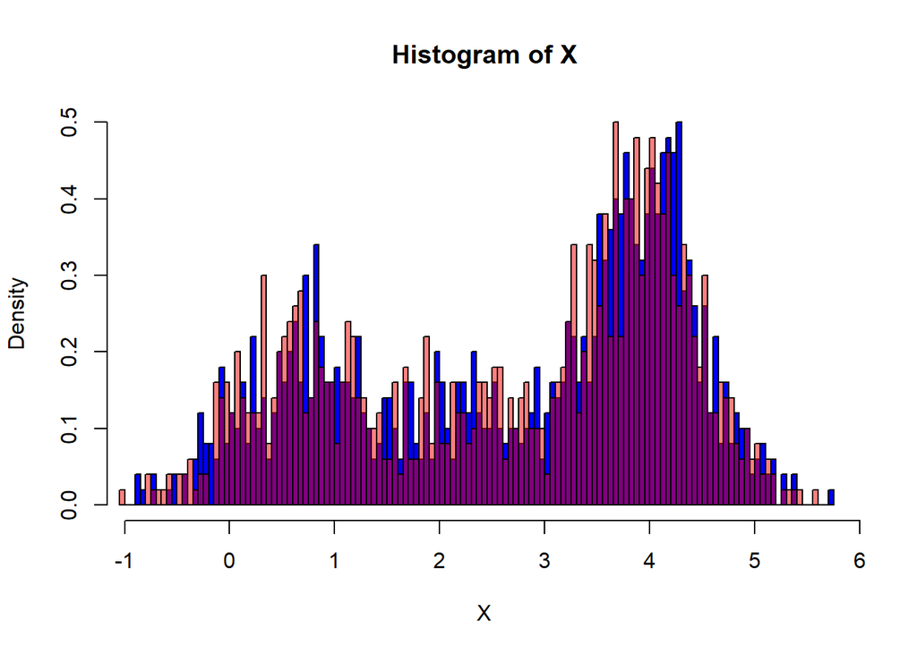

```r
hist(X, prob = TRUE, breaks = 100, col = "blue")
hist(rmixt(n, theta3[1:3, 1], theta3[1:3, 2], theta3[1:3, 3]),
     breaks = 100, prob = TRUE, add = TRUE, col=rgb(1,0,0,0.5))
```

This method works well but is slow. Perhaps use if you expect the three mixed densities to be similar but with different means.

##### 4.

```r
clusters <- kmeans(X, 3)$cluster
theta4 <- fit_em(X, table(clusters) / length(X), tapply(X, clusters, mean),
                 tapply(X, clusters, sd), approx)
theta4
```

```
##              w        mu     sigma
## [1,] 0.1344091 2.2683052 0.4324140
## [2,] 0.5598464 3.9517120 0.5355309
## [3,] 0.3057445 0.6995595 0.6118112
```

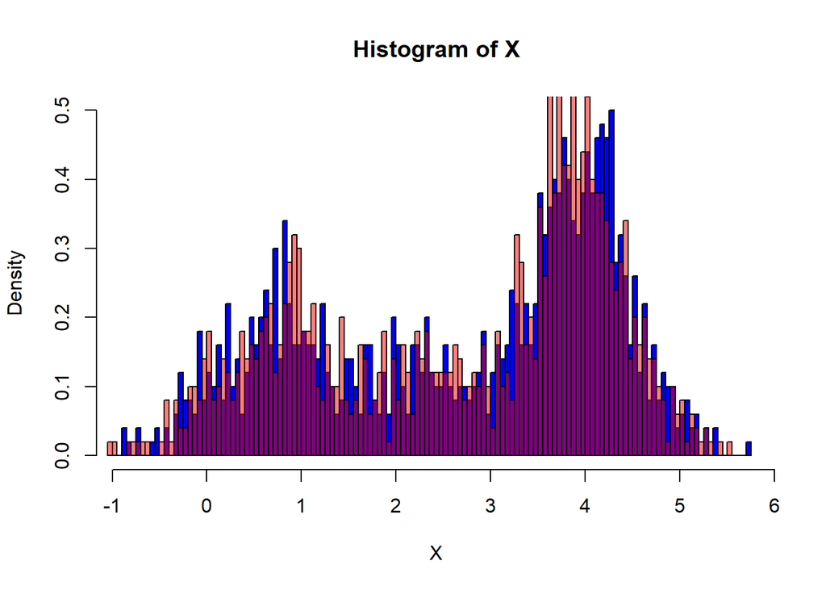

```r
hist(X, prob = TRUE, breaks = 100, col = "blue")
hist(rmixt(n, theta4[1:3, 1], theta4[1:3, 2], theta4[1:3, 3]),
     breaks = 100, prob = TRUE, add = TRUE, col=rgb(1,0,0,0.5))
```

This method works well in general but is slow.

## Exercise 2

Consider the following data:

```r
set.seed(5)
X <- rexp(500)
Y <- 2 + 0.5 * X + rnorm(500)
dat <- data.frame(Y, X)
```

We fit a linear model to this data and compute confidence intervals for both parameters:

```r
fit <- lm(Y ~ X, data = dat)
confint(fit)
```

```
##                 2.5 %    97.5 %
## (Intercept) 1.8057234 2.0463849
## X           0.4971383 0.6585376
```

Now implement a bootstrap algorithm to estimate 95%-confidence intervals for both parameters. Compare your results to the confidence intervals above.

**Solution:**

```r
B <- 1000
n <- dim(dat)[1]
m <- dim(dat)[2]
int_B <- X_B <- numeric(B)
for (b in 1:B) {
  c <- coef(lm(Y ~ X, data = dat[sample.int(n, replace = TRUE), 1:m]))
  int_B[b] <- c[1]
  X_B[b] <- c[2]
}
```

```r
# Intercept 95%-CI bounds:
unname(2 * coef(fit)[1] - quantile(int_B, c(.975, .025)))
```

```
## [1] 1.801575 2.037938
```

```r
# X 95%-CI bounds:
unname(2 * coef(fit)[2] - quantile(X_B, c(.975, .025)))
```

```
## [1] 0.5110705 0.6508859
```

These bounds are a bit tighter than those reported by `confint`. The help-file of that function says its default method “assumes normality”. Let’s just try `boot` to get all kinds of CIs:

```r
library(boot)
f <- function(data, index) coef(lm(Y ~ X, data = dat[index, 1:m]))
int_boot <- boot(dat, function(d, i) f(d, i)[1], R = 1000)
boot.ci(int_boot)
```

```
## BOOTSTRAP CONFIDENCE INTERVAL CALCULATIONS
## Based on 1000 bootstrap replicates
##
## CALL :
## boot.ci(boot.out = int_boot)
##
## Intervals :
## Level      Normal              Basic
## 95%   ( 1.814,  2.042 )   ( 1.809,  2.041 )
##
## Level     Percentile            BCa
## 95%   ( 1.811,  2.043 )   ( 1.805,  2.040 )
## Calculations and Intervals on Original Scale
```

```r
X_boot <- boot(dat, function(d, i) f(d, i)[2], R = 1000)
boot.ci(X_boot)
```

```
## BOOTSTRAP CONFIDENCE INTERVAL CALCULATIONS
## Based on 1000 bootstrap replicates
##
## CALL :
## boot.ci(boot.out = X_boot)
##
## Intervals :
## Level      Normal              Basic
## 95%   ( 0.5116,  0.6435 )   ( 0.5099,  0.6429 )
##
## Level     Percentile            BCa
## 95%   ( 0.5128,  0.6457 )   ( 0.5149,  0.6460 )
## Calculations and Intervals on Original Scale
```